# hw7_mark

Ruizhou Peng

2023-12-05

first load package

```r
library(tidyverse)
```

## 1. Maximum likelihood estimates

### 1.1 Maximum likelihood estimates for Red tailed hawks

we will fit a Gaussian model to a Red-tailed hawk data set

```r
library(Stat2Data)
data('Hawks')
```

**q1**:

extract a subset so that every Hawk belongs to the ‘Red-tailed’ species, along with “Weight”,“Tail” and “Wing” columns. The returned output is a data frame called “RedTailedDf”

```r
RedTailedDf <- Hawks%>%
  filter(Species=="RT")%>%
  select(Weight, Tail, Wing)

head(RedTailedDf, 5)
```

```
##   Weight Tail Wing
## 1    920  219  385
## 2    930  221  376
## 3    990  235  381
## 4   1090  230  412
## 5    960  212  370
```

**q2**:

compute the estimates $\hat{\mu}_{MLE}$ and $\hat{\sigma}_{MLE}^2$ for tail lengths using “RedTailedDf”

```r
# compute MLE mean
mean_mle <- mean(RedTailedDf$Tail, na.rm=TRUE)

# compute MLE variance
variance_mle <- sum((RedTailedDf$Tail-mean_mle)^2, na.rm=TRUE)/length(RedTailedDf$Tail)
```

**q3**:

compare the fitted Gaussian model for the tail length of the red-tailed hawks with a kernel density plot

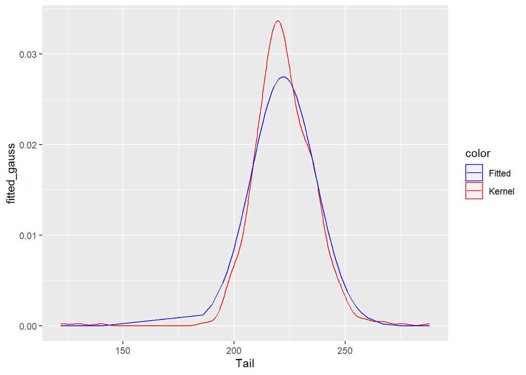

```r
# use dnorm to create a customised normal distribution
# this is the density correspond to RedTailedDf tail
fitted_gauss <- dnorm(RedTailedDf$Tail, mean=mean_mle, sd=sqrt(variance_mle))

# set color in aes
Colors <- c("Kernel"='red', "Fitted"='blue')
ggplot()+
  geom_density(data=select(RedTailedDf,Tail), aes(x=Tail,color='Kernel'))+
  # use line graph to plot the fitted density
  geom_line(data=tibble(RedTailedDf$Tail, fitted_gauss), aes(x=RedTailedDf$Tail, y=fitted_gauss,color='Fitted'))+
  scale_color_manual(name='color', values=Colors)
```

### 1.2 Unbiased estimation of the population variance

**q1**:

conduct a simulation study compares the bias of $\hat{V}_{MLE}$ as an estimate to the population variance $\sigma_0^2$ with the bias of sample variance $\hat{V}_{U}$ as an estimator for the population variance $\sigma_0^2$

```r
# compute mle function
mle_compute <- function(x_seq){
  len <- length(x_seq)
  means <- mean(x_seq, na.rm=TRUE)

  return(sum((x_seq-means)^2)/len)
}

# compute mvue function
mvue_compute <- function(x_seq){
  len <- length(x_seq)
  means <- mean(x_seq, na.rm=TRUE)

  return(sum((x_seq-means)^2)/(len-1))
}

# sample sizes
sample_size <- seq(5,100,5)

# trials number
trial_num <- 1000

# sample N(1, 9)
mu <- 1
sigma <- 3

# using "expand" to generate combination of
# different sample sizes and trial numbers
mle_mvue_df <- data.frame(sample_size, trial_nums=1:trial_num)%>%
  expand(sample_size, trial_nums)%>%
  # sample each sequence of random variables
  mutate(samples=map(sample_size, ~rnorm(.x, mu, sigma)))%>%
  # compute mle and mvue
  mutate(mle=map_dbl(samples, mle_compute),
         mvue=map_dbl(samples, mvue_compute))%>%
  # group by sample_size use average mle and mvue
  select(sample_size, mle, mvue)%>%
  group_by(sample_size)%>%
  summarise(mle_avg=mean(mle), mvue_avg=mean(mvue))

# compute bias of mle and mvue
bias_mle_mvue_df <- mle_mvue_df%>%
  mutate(across(c(mle_avg,mvue_avg),~.x-sigma^2,
                .names="{.col}_bias")
         )
```

after getting the bias of the mle and mvue, we use line plots to show them

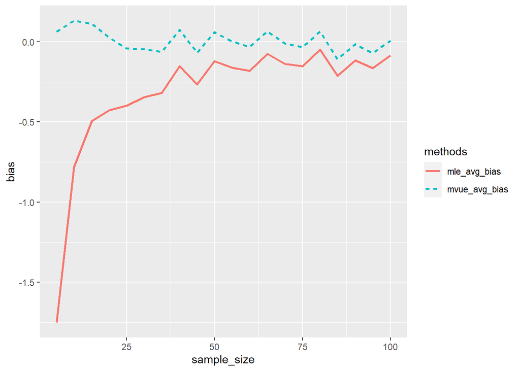

```r
# the data frame is not tidy, now tidy it longer
bias_mle_mvue_tidy_df <- bias_mle_mvue_df%>%
  pivot_longer(cols=c(mle_avg_bias, mvue_avg_bias),
               names_to = 'methods',
               values_to = 'bias')

bias_mle_mvue_tidy_df%>%
  ggplot(aes(x=sample_size, y=bias, color=methods, linetype=methods))+
  geom_line(linewidth=1)
```

**q2**:

yes, I think $\sqrt{\hat{V_U}} = \sqrt{\frac{1}{n-1}\sum_{i=1}^n(X_i-\overline{X})^2}$ is unbiased estimator

still using the previous example, let’s compute the $\sqrt{\hat{V_U}}$

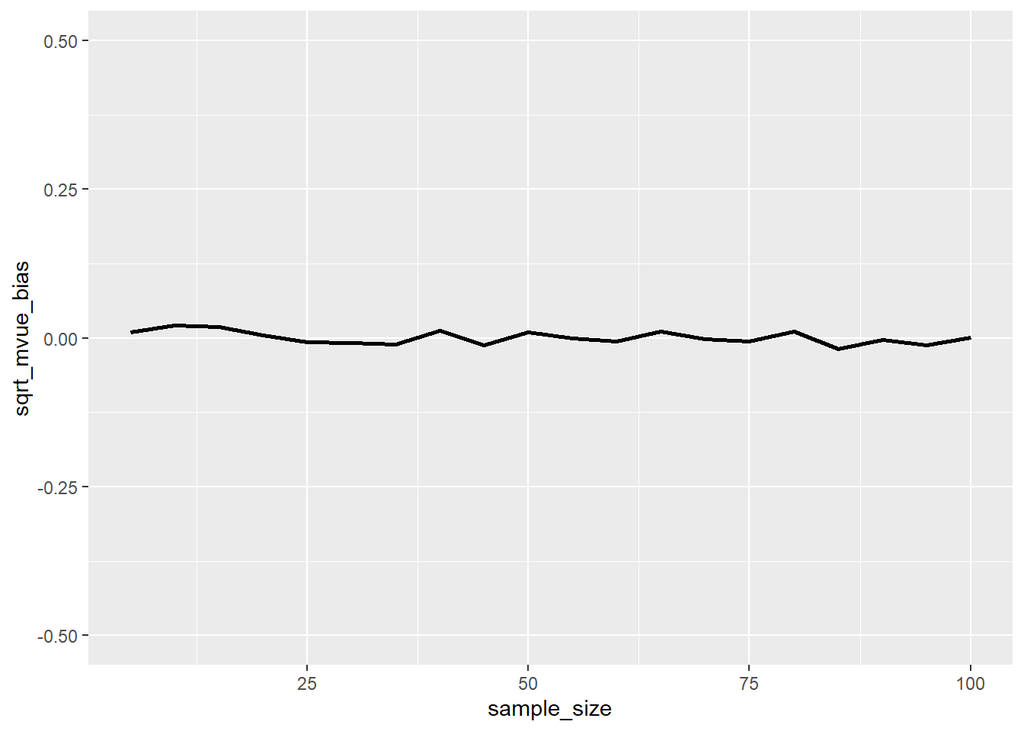

```r
# use the previous mle_mvue_df to compute sqrt(mvue)
bias_sqrt_mvue_df <- mle_mvue_df%>%
  select(sample_size, mvue_avg)%>%
  mutate(sqrt_mvue_bias=sqrt(mvue_avg)-sigma)

# use line plot to show
bias_sqrt_mvue_df%>%ggplot(aes(x=sample_size, y=sqrt_mvue_bias))+
  geom_line(linewidth=1)+ylim(-0.5:0.5)
```

according to the plot, whenever the sample size big or small, the bias of $\sqrt{\hat{V_U}}$ is always near 0. so it is unbiased estimator for $\sigma_0$

### 1.3 Maximum likelihood estimation with the Poisson distribution

**q1**:

suppose $X_i\in \mathbb{N}_0$, otherwise, the likelihood fnction will be 0
$$l(\lambda)=\prod_{i=1}^n p_{\lambda}(X_i)
\\=\prod_{i=1}^n \frac{\lambda^{X_i}e^{-\lambda}}{X_i!}
\\=\frac{\prod_{i=1}^n\lambda^{X_i}e^{-\lambda}}{\prod_{i=1}^n X_i!}
\\=e^{-n\lambda}\cdot\lambda^{n\cdot \overline{X}}\cdot \left(
\prod_{i=1}^n \frac{1}{X_i !} \right)$$
where $\overline{X}=\frac{1}{n}\sum_{i=1}^n X_i$

the log-likelihood $\frac{\partial}{\partial \lambda} log\; l(\lambda)$ is:

$$log\;l(\lambda)=(-n\lambda) + (n\cdot
\overline{X})log\lambda-\sum_{i=1}^n log(X_i!)
\\\frac{\partial}{\partial \lambda} log\; l(\lambda)=-n+\frac{n\cdot
\overline{X}}{\lambda}$$

**q2**:

when $\frac{\partial}{\partial \lambda} log\; l(\lambda)=0$, it reaches its maximum point, so that $\lambda=\overline{X}$

**q3**:

conduct a simulation experiment which explore the behaviour of $\hat{\lambda}_{MLE}$, you may wish to condider a setting in which $\lambda_o=0.5$ and generate a plot of the mean squared error as a function of the sample size

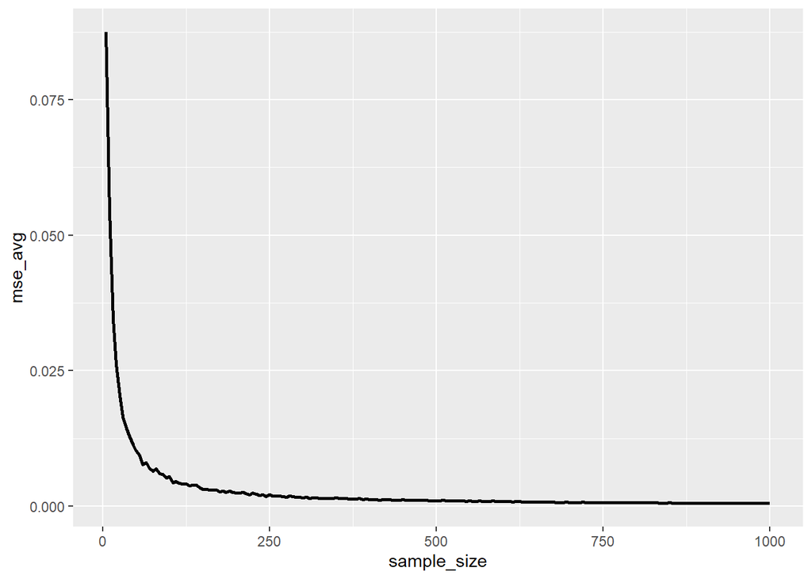

```r
# check whether X_mean is the MLE estimator of lambda
lambda <- 0.5

# set a sample size
sample_size <- seq(5,1000, 5)

# each sample size we conduct 1000 trials
trial_num <- 1000

mle_lambda_df <- data.frame(sample_size, trial_nums=1:trial_num)%>%
  # use expand to get combination of sample size and trials
  expand(sample_size, trial_nums)%>%
  # sample Poisson variables
  mutate(samples=map(sample_size, ~rpois(.x, lambda)))%>%
  # compute x_mean
  mutate(x_mean = map_dbl(samples, mean))%>%
  # compute mean square error
  mutate(mse= map_dbl(x_mean, ~(.x-lambda)^2))%>%
  # get the average mse based on sample sizes
  group_by(sample_size)%>%
  summarise(mse_avg=mean(mse))

# use plot to show
mle_lambda_df%>%
  ggplot(aes(x=sample_size, y=mse_avg))+geom_line(linewidth=1)
```

**q4**:

read the **VonBortkiewicz.csv**, model the values in **fatalities** as independent random variables from a Poisson distribution with parameter $\lambda_0$ and compute the maximum likelihood estimate $\hat{\lambda}_{MLE}$ for $\lambda_0$

use fitted Poisson model to give an estimate for the probability that a single cavalry corps has no fatalities due to horse kicks in a single year

```r
# firstly read in the csv file
VB <- read.csv("VonBortkiewicz.csv", header=TRUE)

# see fatalities as variables
mle_lambda <- mean(VB$fatalities, na.rm = TRUE)

# compute the probability that a single cavalry corps has no fatalities due to horse kicks

fatalities <- 0
prob <- dpois(fatalities, mle_lambda)
print(paste("the probability of no fatalities is: ", round(prob*100,2), "%", sep=""))
```

```
## [1] "the probability of no fatalities is: 49.66%"
```

**q5**:

since each incident has the same probability to happen, so the probability of incident happen is $\frac{1}{n}$
$$I(\lambda) = -
\mathbb{E}(\frac{\partial^2}{\partial\lambda^2}log\;p_{\lambda}(X))=-\frac{1}{n}\cdot
n\overline{X}\cdot\frac{(-1)}{\lambda^2}=\frac{\overline{X}}{\lambda^2}$$
now sample 1000 Possion random variables with $\lambda=0.5$

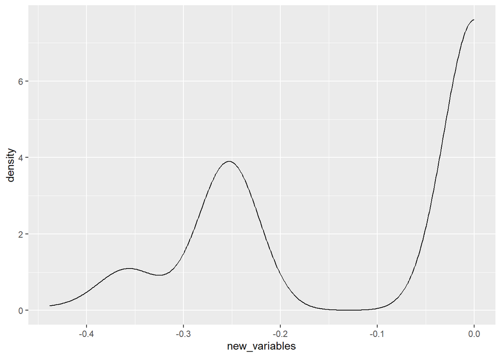

```r
sample_size <- 1000
lambda <- 0.5
sample_pois <- rpois(sample_size, lambda)

# first compute MLE_lambda
mle_lambda <- mean(sample_pois, na.rm=TRUE)

# compute sqrt(nI)(mle_lambda- lambda)
new_variables <- sqrt(sample_size*sample_pois/lambda^2)*(mle_lambda-lambda)

# give a kernel density plot
ggplot(data=tibble(new_variables), aes(x=new_variables))+
  geom_density()
```

### 1.4 Maximum likelihood estimation for theexponential distribution

**q1**:

suppose all $X_n \ge 0$ otherwise the likelihood will be 0

$$l(\lambda) = \prod_{i=1}^n p_{\lambda}(X_i)
\\=\lambda^n e^{-\lambda\sum_{i=1}^n Xi}
\\log\;l(\lambda)=nlog(\lambda)-\lambda\sum_{i=1}^n Xi
\\\frac{\partial}{\partial\lambda}log\;l(\lambda)=\frac{n}{\lambda}-\sum_{i=1}^n
X_i=0
\\\therefore \lambda=\frac{n}{\sum_{i=1}^n X_i}=\frac{1}{\overline{X}}$$

**q2**:

add a new column which gives the time in seconds until the next customer’s purchase

```r
# read in csv
CP <- read.csv("CustomerPurchase.csv")

# add a new column compute the differ in adjacent time
# use "lead" function to achieve this
# lead--->find next,   lag----> find previous
CP<- CP%>%mutate(time_diffs=lead(Time)-Time)

# check
tail(CP, 5)
```

```
##      Time Purchase time_diffs
## 636 32080   112.75        186
## 637 32266   101.70         52
## 638 32318     2.95         58
## 639 32376     1.50         14
## 640 32390   370.70         NA
```

**q3**:

```r
# according to question1, the mle is 1/(n*mean)

# first compute the length of not none
len <- sum(!CP%>%pull(time_diffs)%>%is.na())

# compute mle
mle_lambda <- 1/(mean(CP$time_diffs, na.rm=TRUE))
```

**q4**:

use fitted exponential model to give an estimate of the probability of an arrival time in excess of one minute

```r
# estimate the probability where X >= 60 sec
# that is, the probability of 1-p(x<60)

# using distribution function, lower.tail=False means compute p>60
prob<- pexp(60, mle_lambda, lower.tail = FALSE)

print(paste("the probability of an arrival time in excess of 60 seconds is: ", round(prob*100,2), "%"))
```

```
## [1] "the probability of an arrival time in excess of 60 seconds is:  29.98 %"
```

## 2. Confidence intervals

### 2.1 Student’s t-confidence intervals

**q1**:

If the sample mean were higher, the width of the confidence interval will not change while the position will.

If the sample standard deviation were higher, the width will grow.

If the sample size were higher keeping the sample standard deviation the same, the width will shrink.

**q2**:

extract a vector consisting of the weights of all the Red-Tailed hawks with missing values removed

```r
RT_Weight <- Hawks%>%filter(Species=='RT'& !is.na(Weight))%>%pull(Weight)
```

use Student’s t method to compute 99%-level confidence intervals for the population mean

```r
# set significant level
alpha <- 0.01

sample_mean <- mean(RT_Weight, na.rm=TRUE)
sample_sd <- sd(RT_Weight, na.rm=TRUE)
sample_size <- length(RT_Weight)

t <- qt(1-alpha/2, df=sample_size-1)

# compute confidence interval
confidence_interval_l <- sample_mean-t*sample_sd/sqrt(sample_size)
confidence_interval_u <- sample_mean+t*sample_sd/sqrt(sample_size)
confidence_interval <- c(confidence_interval_l, confidence_interval_u)

print(confidence_interval)
```

```
## [1] 1073.984 1114.877
```

```r
print(paste("sample mean:" ,sample_mean))
```

```
## [1] "sample mean: 1094.43006993007"
```

**q3**:

when using student’s t-distribution, it need to assume that the random variables are Gaussian random variables

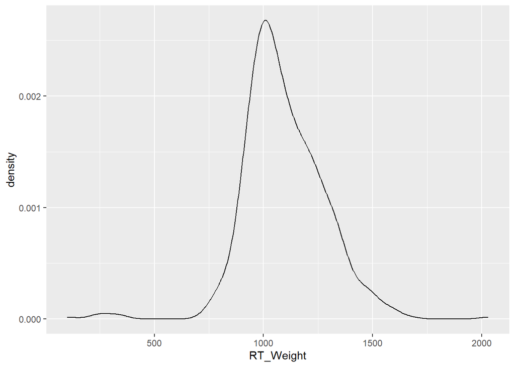

```r
# check assumption using density plot and qqplot
ggplot(data=tibble(RT_Weight), aes(x=RT_Weight))+geom_density()
```

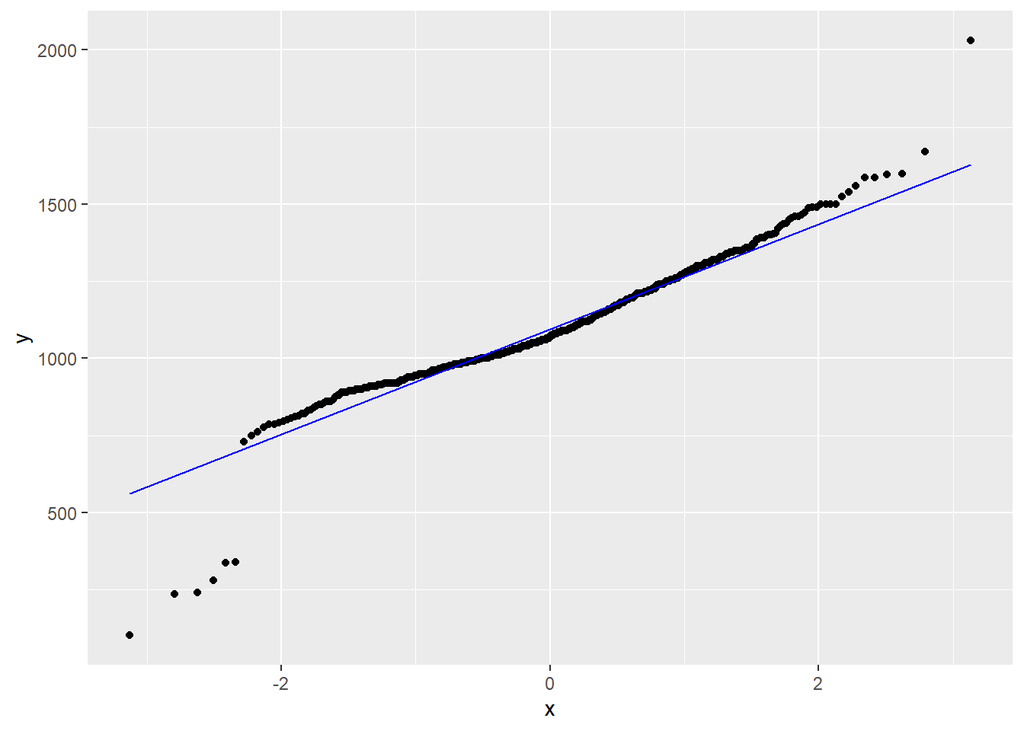

```r
ggplot(data=tibble(RT_Weight), aes(sample=RT_Weight))+stat_qq(aes(sample=RT_Weight))+stat_qq_line(color="blue")
```

From qq plot, it aligns with Gaussian distribution of that mean and sd apart from a few outliers.

### 2.2 Investigating coverage for Student’s t intervals

**q1**:

```r
student_t_confidence_interval <- function(sample, confidence_level){
  # remove missing values
  sample <- sample[!is.na(sample)]

  # size, mean and sd
  size <- length(sample)
  mean_t <- mean(sample, na.rm=TRUE)
  sd_t <- sd(sample, na.rm=TRUE)

  # compute quantile
  alpha <- 1-confidence_level
  t <- qt(1-alpha/2, size-1)

  # compute interval
  t_lower <- mean_t-t*sd_t/sqrt(size)
  t_upper <- mean_t+t*sd_t/sqrt(size)

  return(c(t_lower, t_upper))
}
```

then modify the code

```r
num_trials <- 10000
sample_size <- 30

mu_0 <- 1
sigma_0 <- 3
alpha <- 0.05

set.seed(0)

single_alpha_coverage_simulation_df <- data.frame(trial=seq(num_trials))%>%
  # generate random Gaussian samples:
  mutate(samples=map(trial, ~rnorm(sample_size, mu_0, sigma_0)))%>%
  # generate confidence intervals:
  mutate(ci_interval=map(samples, ~student_t_confidence_interval(.x, 1-alpha)))%>%
  # check if interval covers mu_0, map_lgl returns a boolean:
  mutate(cover=map_lgl(ci_interval, ~((min(.x)<=mu_0)&(max(.x)>=mu_0))))%>%
  # compute interval length:
  mutate(ci_length=map_dbl(ci_interval, ~(max(.x)-min(.x))))

# show df
# head(single_alpha_coverage_simulation_df, 5)

# estimate of coverage probability:
single_alpha_coverage_simulation_df%>%pull(cover)%>%
  mean()
```

```
## [1] 0.9522
```

**q1**:

modify the code to conduct a simulation experiment to investigate how $\mathbb{P}\{ (L_\alpha(X_1,...,X_n) \le\mu_0\le R_\alpha(X_1,...,X_n))\}$ varies as a function of the confidence level $\gamma=1-\alpha$

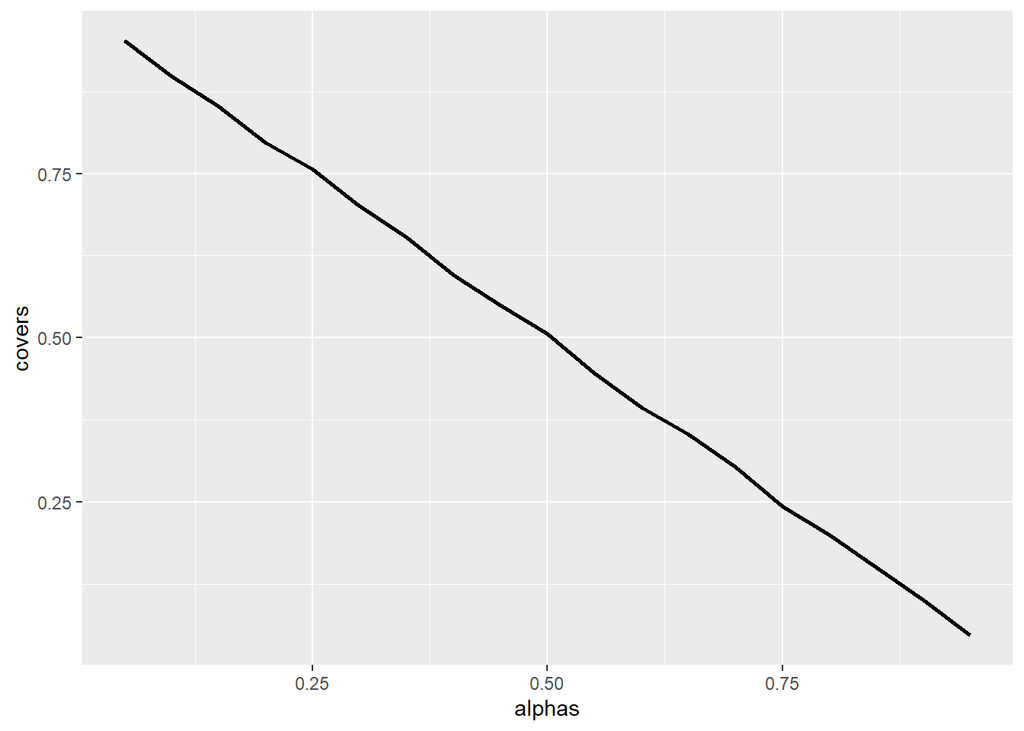

```r
num_trials <- 10000
sample_size <- 30

mu_0 <- 1
sigma_0 <- 3
# change alpha to a sequence
alphas <- seq(0.05,0.95,0.05)
trials <- seq(num_trials)
nrow <- length(alphas)*length(trials)
set.seed(0)

alphas_coverage_simulation_df <-
  # Cartesian Product different alphas with trials
  expand.grid(trials=trials,alphas=alphas)%>%
  # generate index
  mutate(index=1:nrow)%>%
  # generate random Gaussian samples:
  mutate(samples=map(index, ~rnorm(sample_size, mu_0, sigma_0)))%>%
  # generate confidence intervals:
  mutate(ci_interval=map2(samples,alphas, ~student_t_confidence_interval(.x, 1-.y)))%>%
  # check if interval covers mu_0, map_lgl returns a boolean:
  mutate(cover=map_lgl(ci_interval, ~((min(.x)<=mu_0)&(max(.x)>=mu_0))))%>%
  # compute interval length:
  mutate(ci_length=map_dbl(ci_interval, ~(max(.x)-min(.x))))

# compute cover rate with alphas vary
alphas_coverage_df <- alphas_coverage_simulation_df%>%
  # group by alpha
  group_by(alphas)%>%
  # compute average coverage rate
  summarize(covers=mean(cover))

# use line plot to show
alphas_coverage_df%>%
  ggplot(aes(x=alphas, y=covers))+geom_line(linewidth=1)
```

**q2**:

explore how the average length of confidence interval vary as a function of the confidence level $\gamma=1-\alpha$

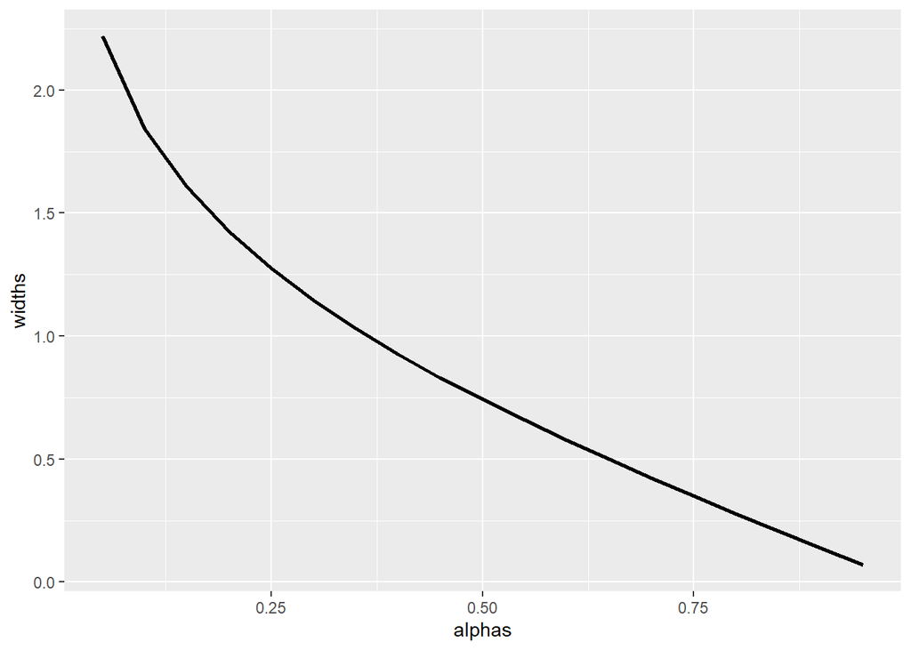

```r
ci_width_df <- alphas_coverage_simulation_df%>%
  # group by alpha
  group_by(alphas)%>%
  # compute average ci width
  summarise(widths=mean(ci_length))

# use line plot to show
ci_width_df%>%
  ggplot(aes(x=alphas, y=widths))+geom_line(linewidth=1)
```

## 3. One sample hypothesis testing

### 3.1 One sample t-test on penguins data

**q1**:

load the “Palmer penguins”

```r
# load data
library(palmerpenguins)
data(penguins)

head(penguins)
```

```
## # A tibble: 6 × 8
##   species island    bill_length_mm bill_depth_mm flipper_length_mm body_mass_g
##   <fct>   <fct>              <dbl>         <dbl>             <int>       <int>
## 1 Adelie  Torgersen           39.1          18.7               181        3750
## 2 Adelie  Torgersen           39.5          17.4               186        3800
## 3 Adelie  Torgersen           40.3          18                 195        3250
## 4 Adelie  Torgersen           NA            NA                  NA          NA
## 5 Adelie  Torgersen           36.7          19.3               193        3450
## 6 Adelie  Torgersen           39.3          20.6               190        3650
## # ℹ 2 more variables: sex <fct>, year <int>
```

extract a vector called “bill_adelie” consisting of the bill lengths which belongs to the Adelie species

```r
# extract vector
bill_adelie <- penguins%>%filter(species=='Adelie')%>%
  pull(bill_length_mm)
```

test that the population mean of the Adelie penguin’s bill lengths is 40mm. Use a significance level of 0.01.

```r
# h0: bill_mean = 40
# h1: bill_mean != 40

# remove missing values
bill_adelie <- bill_adelie[!is.na(bill_adelie)]
mean_true <- 40
confidence_level <- 0.99
t.test(bill_adelie, mu=mean_true, conf.level = confidence_level)
```

```
##
##  One Sample t-test
##
## data:  bill_adelie
## t = -5.5762, df = 150, p-value = 1.114e-07
## alternative hypothesis: true mean is not equal to 40
## 99 percent confidence interval:
##  38.22590 39.35688
## sample estimates:
## mean of x
##  38.79139
```

### 3.2 Implementing a one-sample t-test

**q1**:

implementing a function that carries out a two-sided one-sample t-test

input arguments are:

1. a vector x corresponding to a sample
2. the value mu_0 corresponding to the null hypothesis

the output is the p-value of the test

```r
t_test_implement <- function(x, mu){
  # first compute T
  # we need mean, variance and size

  # remove missing values
  x <- x[!is.na(x)]

  len <- length(x)
  mean_x <- mean(x)
  sd_x <- sd(x)

  # compute T
  T_x <- (mean_x-mu)/(sd_x/sqrt(len))

  # compute p value
  # p=p(|t|>T)<=alpha
  # two-sided: P=2*(1-p(t<=T))
  # one-sided: P=1-p(t<=T)
  p_value <- 2*(1-pt(abs(T_x), len-1))

  return(p_value)
}
```

check

```r
# check
p_value <- t_test_implement(bill_adelie, mean_true)

p_value
```

```
## [1] 1.114322e-07
```